# Predictive Distributions

Standard MCMC sampling methods return values of the parameters of the model. However, it is often also useful to generate new data points using the model, given a distribution of the parameters. Turing.jl allows you to do this using the `predict` function, along with conditioning syntax.

Consider the following simple model, where we observe some normally-distributed data `X` and want to learn about its mean `m`.

```julia
using Turing
@model function f(N)
    m ~ Normal()
    X ~ filldist(Normal(m), N)
end
```

```
f (generic function with 2 methods)
```

Notice first how we have not specified `X` as an argument to the model. This allows us to use Turing’s conditioning syntax to specify whether we want to provide observed data or not.

**Note**

If you want to specify `X` as an argument to the model, then to mark it as being unobserved, you have to instantiate the model again with `X = missing` or `X = fill(missing, N)`. Whether you use `missing` or `fill(missing, N)` depends on whether `X` is treated as a single distribution (e.g. with `filldist` or `product_distribution`), or as multiple independent distributions (e.g. with `.~` or a for loop over `eachindex(X)`). This is rather finicky, so we recommend using the current approach: conditioning and deconditioning `X` as a whole should work regardless of how `X` is defined in the model.

```julia
# Generate some synthetic data
N = 5
true_m = 3.0
X = rand(Normal(true_m), N)

# Instantiate the model with observed data
model = f(N) | (; X = X)

# Sample from the posterior
chain = sample(model, NUTS(), 1_000; progress=false)
mean(chain[@varname(m)])
```

```
┌ Info: Found initial step size
└   ϵ = 1.6
```

```
2.6152122217805958
```

## Posterior predictive distribution

`chain[@varname(m)]` now contains samples from the posterior distribution of `m`. If we use these samples of the parameters to generate new data points, we obtain the *posterior predictive distribution*. Statistically, this is defined as

$$p(\tilde{x} | \mathbf{X}) = \int p(\tilde{x} | \theta) p(\theta | \mathbf{X}) d\theta,$$

where $\tilde{x}$ are the new data which you wish to draw, $\theta$ are the model parameters, and $\mathbf{X}$ are the observed data. $p(\tilde{x} | \theta)$ is the distribution of the new data given the parameters, which is specified in the Turing.jl model (the `X ~ ...` line); and $p(\theta | \mathbf{X})$ is the posterior distribution, as given by the Markov chain.

To obtain samples of $\tilde{x}$, we need to first remove the observed data from the model (or ‘decondition’ the model). This means that when the model is evaluated, it will sample a new value for `X`. If you don’t decondition the model, then `X` will remain fixed to the observed data, and no new samples will be generated.

```julia
predictive_model = decondition(model)
```

```
DynamicPPL.Model{typeof(f), (:N,), (), (), Tuple{Int64}, Tuple{}, DynamicPPL.DefaultContext, false}(f, (N = 5,), NamedTuple(), DynamicPPL.DefaultContext())
```

**TipSelective deconditioning**

If you only want to decondition a single variable `X`, you can use `decondition(model, @varname(X))`.

To demonstrate how this deconditioned model can generate new data, we can fix the value of `m` to be its mean and evaluate the model:

```julia
predictive_model_with_mean_m = predictive_model | (; m = mean(chain[@varname(m)]))
rand(predictive_model_with_mean_m)
```

```
VarNamedTuple
└─ X => [2.2914502285797487, 4.177695567885789, 2.8466469986432115, 1.905489637664491, 3.442524395218404]
```

This has given us a single sample of `X` given the mean value of `m`. Of course, to take our Bayesian uncertainty into account, we want to use the full posterior distribution of `m`, not just its mean. To do so, we use `predict`, which *effectively* does the same as above but for every sample in the chain:

```julia
predictive_samples = predict(predictive_model, chain)
```

```
╭─FlexiChain (1000 iterations, 1 chain) ───────────────────────────────────────╮
│ ↓ iter  = 501:1500                                                           │
│ → chain = 1:1                                                                │
│                                                                              │
│ Parameters (2) ── AbstractPPL.VarName                                        │
│  Float64          m                                                          │
│  Vector{Float64}  X (5,)                                                     │
│                                                                              │
│ Extras (14)                                                                  │
│  Int64    n_steps, tree_depth                                                │
│  Bool     is_accept, numerical_error                                         │
│  Float64  acceptance_rate, log_density, hamiltonian_energy,                  │
│           hamiltonian_energy_error, max_hamiltonian_energy_error, step_size, │
│           nom_step_size, logprior, loglikelihood, logjoint                   │
╰──────────────────────────────────────────────────────────────────────────────╯
```

**TipReproducibility**

`predict`, like many other Julia functions that involve randomness, takes an optional `rng` as its first argument. This controls the generation of new `X` samples, and makes your results reproducible.

**Note**

`predict` returns a FlexiChain object itself, which will contain all the original parameters plus the newly predicted variables. If you want to only include the newly predicted variables, you can use `predict(rng, predictive_model, chain; include_all=false)`.

We can visualise the predictive distribution by combining all the samples and making a density plot:

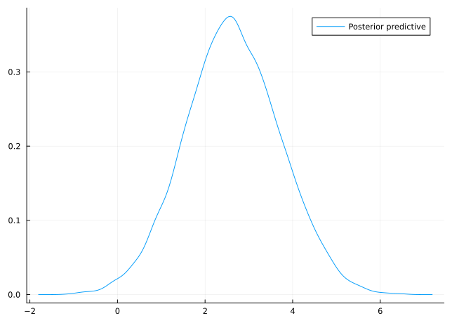

```julia
using StatsPlots: density, density!, vline!

predicted_X = vec(predictive_samples[@varname(X), stack=true])
density(predicted_X, label="Posterior predictive")
```

Depending on your data, you may naturally want to create different visualisations. For example, perhaps `X` contains some time-series data, in which case you can plot each prediction individually as a line against time.

## Prior predictive distribution

Alternatively, if we use the prior distribution of the parameters $p(\theta)$, we obtain the *prior predictive distribution*:

$$p(\tilde{x}) = \int p(\tilde{x} | \theta) p(\theta) d\theta,$$

In an exactly analogous fashion to above, you could sample from the prior distribution of the conditioned model, and *then* pass that to `predict`:

```julia
prior_params = sample(model, Prior(), 1_000; progress=false)
prior_predictive_samples = predict(predictive_model, prior_params)
```

```
╭─FlexiChain (1000 iterations, 1 chain) ───────────────────────────────────────╮
│ ↓ iter  = 1:1000                                                             │
│ → chain = 1:1                                                                │
│                                                                              │
│ Parameters (2) ── AbstractPPL.VarName                                        │
│  Float64          m                                                          │
│  Vector{Float64}  X (5,)                                                     │
│                                                                              │
│ Extras (3)                                                                   │
│  Float64  logprior, loglikelihood, logjoint                                  │
╰──────────────────────────────────────────────────────────────────────────────╯
```

In fact there is a simpler way: you can directly sample from the deconditioned model, using Turing’s `Prior` sampler. This will, in a single call, generate prior samples for both the parameters as well as the new data.

```julia
prior_predictive_samples = sample(predictive_model, Prior(), 1_000; progress=false)
```

```
╭─FlexiChain (1000 iterations, 1 chain) ───────────────────────────────────────╮
│ ↓ iter  = 1:1000                                                             │
│ → chain = 1:1                                                                │
│                                                                              │
│ Parameters (2) ── AbstractPPL.VarName                                        │
│  Float64          m                                                          │
│  Vector{Float64}  X (5,)                                                     │
│                                                                              │
│ Extras (3)                                                                   │
│  Float64  logprior, loglikelihood, logjoint                                  │
╰──────────────────────────────────────────────────────────────────────────────╯
```

We can visualise the prior predictive distribution in the same way as before. Let’s compare the two predictive distributions:

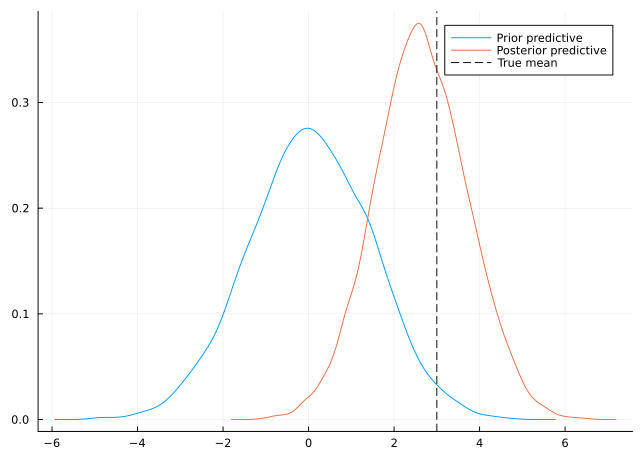

```julia
prior_predicted_X = vec(prior_predictive_samples[@varname(X), stack=true])
density(prior_predicted_X, label="Prior predictive")
density!(predicted_X, label="Posterior predictive")
vline!([true_m], label="True mean", linestyle=:dash, color=:black)
```

We can see here that the prior predictive distribution is:

1. Wider than the posterior predictive distribution;
2. Centred on the prior mean of `m` (which is 0), rather than the posterior mean (which is close to the true mean of `3`).

Both of these are because the posterior predictive distribution has been informed by the observed data.

Back to top